# Tracking Weather Patterns with ‘riem’

Kathleen Scopis

2023-09-26

# Introduction

Planners and public decision makers often rely on analyses relating to geography and the natural environment. From predicting train delays to addressing climate change, it is important to know historic weather patterns for an area in order to better make predictions for the future. The *‘riem’* package helps to select ASOS stations (more on that below) and report on the area’s historical weather-related sensor readings. The package is clean and simple to use, able to pull holistic data with just a few lines of code.

## Step 1: Loading ‘riem’ Package

Before you can use the package’s functions to pull data, it must first be loaded into the environment. Using *install.packages()* and *library()*, install the *riem* package and activate it in the project’s library.

```r
#install.packages('riem')
library(riem)
```

```r
# other libraries needed for plotting
library(tidyverse)
library(ggplot2)
```

## Step 2: ASOS Network List

*‘riem’* pulls information from the **Automated Surface/Weather Observing Systems (ASOS)**. In order to select from the correct station, first access the list of ASOS networks using the *riem_networks()* command.

```r
riem_networks()
```

```
## # A tibble: 264 × 2
##    code     name
##    <chr>    <chr>
##  1 AE__ASOS United Arab Emirates ASOS
##  2 AF__ASOS Afghanistan ASOS
##  3 AG__ASOS Antigua and Barbuda ASOS
##  4 AI__ASOS Anguilla ASOS
##  5 AK_ASOS  Alaska ASOS
##  6 AL__ASOS Albania ASOS
##  7 AL_ASOS  Alabama ASOS
##  8 AM__ASOS Armenia ASOS
##  9 AN__ASOS Netherlands Antilles ASOS
## 10 AO__ASOS Angola ASOS
## # … with 254 more rows
```

## Step 3: ASOS Station List

For this example, we will be observing sensor readings from Richmond, a city in Virginia. To acquire the station ID, input the corresponding network code obtained from running *riem_networks()*. According to the last step, Virginia’s corresponding ASOS network code is ‘VA_ASOS’.

```r
riem_stations(network = 'VA_ASOS')
```

```
## # A tibble: 71 × 28
##    index id    synop name    state country eleva…¹ network online county clima…²
##    <int> <chr> <dbl> <chr>   <chr> <chr>     <dbl> <chr>   <lgl>  <chr>  <chr>
##  1     0 VJI   53818 Abingd… VA    US         631  VA_ASOS TRUE   Washi… VA0021
##  2     1 BKT   13726 Blacks… VA    US         126. VA_ASOS TRUE   Notto… VA1322
##  3     2 VBW      NA Bridge… VA    US         349. VA_ASOS TRUE   Rocki… VA2208
##  4     3 0V4    9999 Brookn… VA    US         179. VA_ASOS TRUE   Campb… VA1082
##  5     4 7W4    9999 Bumpass VA    US         104. VA_ASOS TRUE   Louisa VA5050
##  6     5 CHO   93736 CHARLO… VA    US         195  VA_ASOS TRUE   Albem… VA1593
##  7     6 CXE    9999 Chase … VA    US         149. VA_ASOS TRUE   Meckl… VA1606
##  8     7 CPK    3701 CHESAP… VA    US           6  VA_ASOS TRUE   Chesa… VA6139
##  9     8 FCI     153 Cheste… VA    US          72  VA_ASOS TRUE   Chest… VA7201
## 10     9 W63    9999 Clarks… VA    US         115. VA_ASOS TRUE   Meckl… VA1606
## # … with 61 more rows, 17 more variables: wfo <chr>, modified <chr>,
## #   spri <int>, tzname <chr>, iemid <int>, archive_begin <chr>, metasite <lgl>,
## #   ugc_county <chr>, ugc_zone <chr>, ncdc81 <chr>, ncei91 <chr>,
## #   longitude <dbl>, latitude <dbl>, plot_name <chr>, archive_end <chr>,
## #   lon <dbl>, lat <dbl>, and abbreviated variable names ¹elevation,
## #   ²climate_site
```

## Step 4: Pull Station Data

Once the station ID is selected, use *riem_measures()* to obtain historical weather data. The syntax is as follows:

— *station:* station ID

— *date_start:* starting date of the desired data, typically in YYYY-MM-DD format

— *date_end:* ending date of the desired data, typically in YYYY-MM-DD format

The resulting dataset features several columns, each representing a different quality observed by the sensors. The data may include:

— *station*: three or four character site identifier

— *valid:* timestamp of the observation (in UTC)

— *tmpf:* Air Temperature (F), typically @ 2 meters

— *dwpf*: Dew Point Temperature (F), typically @ 2 meters

— *drct*: Wind Direction in degrees from north

— *p01i*: One hour precipitation for the period from the observation time to the time of the previous hourly precipitation reset. This varies slightly by site. Values are in inches. This value may or may not contain frozen precipitation melted by some device on the sensor or estimated by some other means. Unfortunately, we do not know of an authoritative database denoting which station has which sensor. • alti: Pressure altimeter in inches

— *mslp*: Sea Level Pressure in millibar

— *vsby*: Visibility in miles

— *gust*: Wind Gust in knots

— *skyc1*: Sky Level 1 Coverage

— *skyc2*: Sky Level 2 Coverage

— *skyc3:* Sky Level 3 Coverage

— *skyc4*: Sky Level 4 Coverage

— *skyl1:* Sky Level 1 Altitude in feet

— *skyl2:* Sky Level 2 Altitude in feet

— *skyl3*: Sky Level 3 Altitude in feet

— *skyl4:* Sky Level 4 Altitude in feet

— *presentwx:* Present Weather Codes (space seperated), see e.g. Chapter 8 of [this manual](https://www.ofcm.gov/publications/fmh/FMH1/FMH1.pdf) for further explanations.

— *feel*: Apparent Temperature (Wind Chill or Heat Index) in degF

— *ice_accretion_1hr*: Ice Accretion over 1 Hour in inch

— *ice_accretion_3hr*: Ice Accretion over 3 Hour in inch

— *ice_accretion_6hr:* Ice Accretion over 6 Hour in inch

— *metar*: unprocessed reported observation in METAR format

— *peak_wind_gust*: Wind gust in knots from the METAR PK WND remark, this value may be different than the value found in the gust field. The gust field is derived from the standard METAR wind report.

— *peak_wind_drct*: The wind direction in degrees North denoted in the METAR PK WND remark.

— *peak_wind_time*: The timestamp of the PK WND value in the same timezone as the valid field and controlled by the tz parameter.

# Example Analysis

Using the *riem* package, the following code pulls one week of historical weather data for Richmond, VA, then graphs a few significant variables.

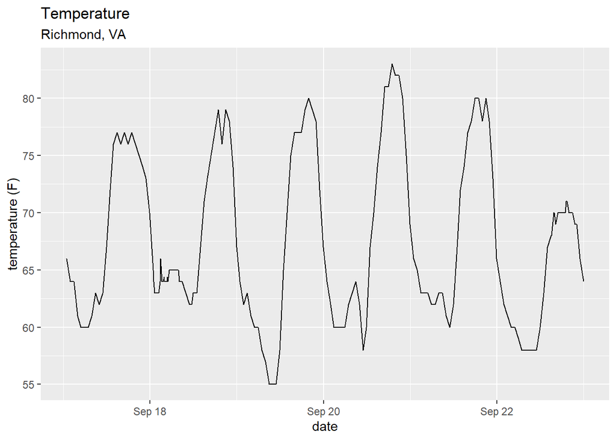

```r
# pull data
weather.Data <- riem_measures(
  station = "OFP",
  date_start = "2023-09-17",
  date_end = "2023-09-23") %>%
  filter(!is.na(tmpf)) # remove NAs

# plot data
par(mfrow = c(2,2))
(ggplot(weather.Data, aes(valid, tmpf))
    + geom_line()
    + labs(title = "Temperature",
           subtitle = "Richmond, VA",
           x = "date",
           y = "temperature (F)")
    )
```

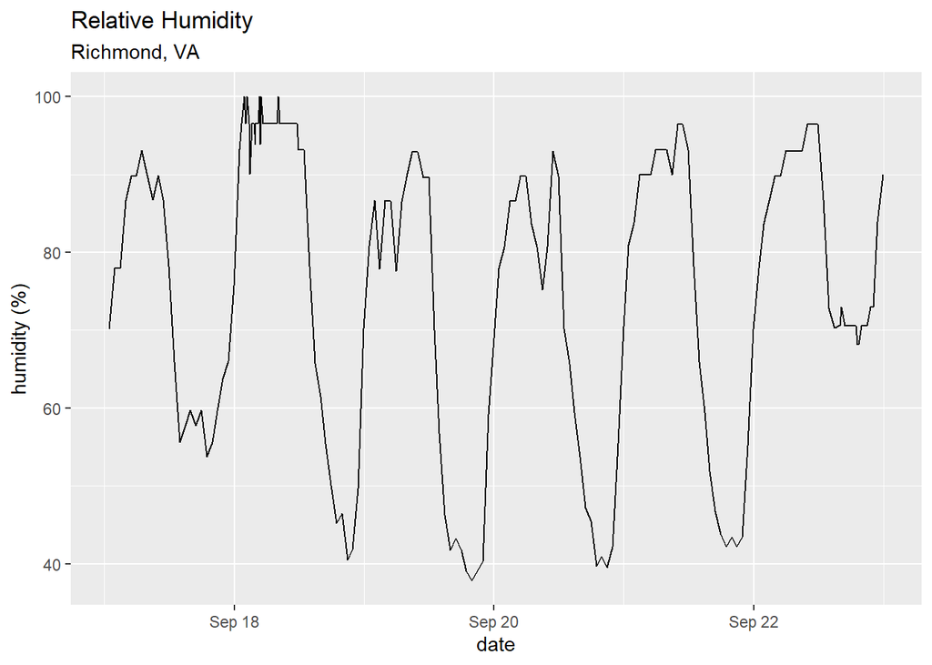

```r
(ggplot(weather.Data, aes(valid, relh))
    + geom_line()
    + labs(title = "Relative Humidity",
           subtitle = "Richmond, VA",
           x = "date",
           y = "humidity (%)")
    )
```

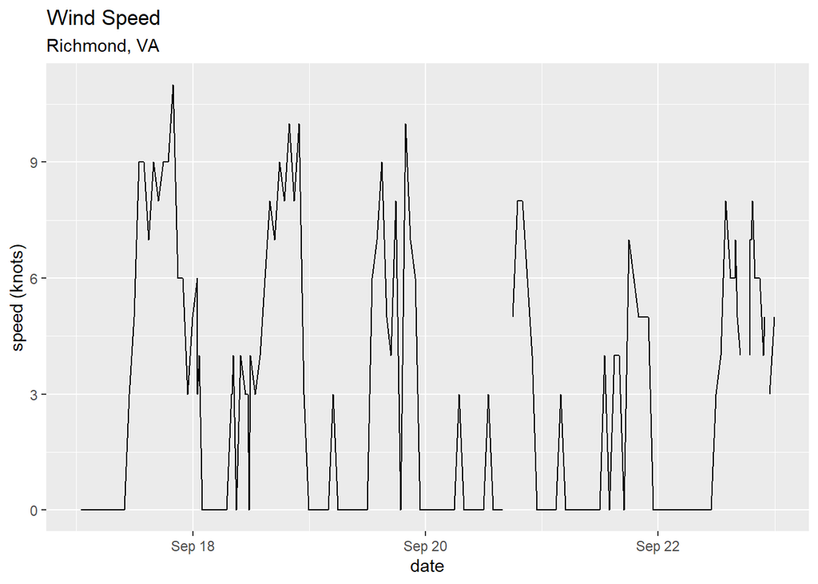

```r
(ggplot(weather.Data, aes(valid, sknt))
    + geom_line()
    + labs(title = "Wind Speed",
           subtitle = "Richmond, VA",
           x = "date",
           y = "speed (knots)")
    )
```

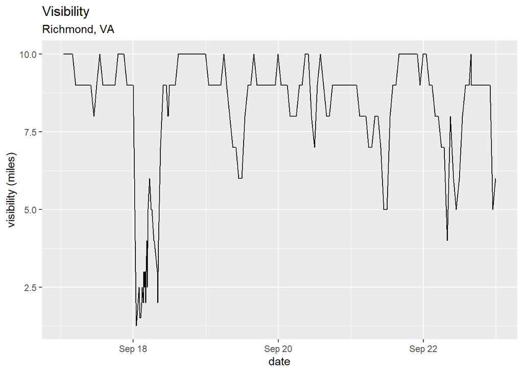

```r
(ggplot(weather.Data, aes(valid, vsby))
    + geom_line()
    + labs(title = "Visibility",
           subtitle = "Richmond, VA",
           x = "date",
           y = "visibility (miles)")
    )
```